# Visualizations for Values and Norms Predicting Conformity or Deviance from Unpopular Norms

Sara Lieber

07/06/2021

# Project Background

This project was a follow-up to a previous study in which we analyzed common unpopular norms among college undergraduates. Unpopular norms are rules about behavior that people widely follow in public yet disagree with privately. In a previous study, when college undergraduates were asked to describe a behavior that they perceived as being widely followed or endorsed but that they did not personally agree with, the following three common behaviors emerged: 1) Wearing fashionable/trendy clothing, 2) Constantly using technology/social media, and 3) Limiting the self-expression of one’s true ideas in conversations with others. The purpose of this follow-up study was to examine the relative importance of personal values versus normative constructs as predictors of conformity with or deviance from these unpopular norms.

# Import data

```r
data <- import("mlm_setup_follow_up_survey_values_norms_GS_Fall19.xlsx")
# glimpse(data)
```

# Cleaning Data

## Renaming variables

```r
data_clean <- data %>%
  rename(Age = Q1.1,
         Gender = Q328,
         Gender_Text = Q328_4_TEXT,
         Ethnicity = Q1.3,
         Ethnicity_Text = Q1.3_17_TEXT)
```

## Cleaning variable types

```r
# str(data_clean)

data_clean <- data_clean %>%
  mutate(Age = as.numeric(Age),
         Gender = as.factor(Gender),
         Ethnicity = as.factor(Ethnicity),
         Behavior = as.factor(Behavior),
         Is_Norm = as.factor(Is_Norm))

levels(data_clean$Is_Norm) <- c("Yes", "No")
levels(data_clean$Is_Norm)
```

```
## [1] "Yes" "No"
```

```r
n_distinct(data_clean$ID) # 320 participants
```

```
## [1] 320
```

## Labeling levels of nominal variables

```r
levels(data_clean$Gender) <- c("Female", "Male", "Non-binary", "Prefer to self-describe", "Prefer not to say")
levels(data_clean$Ethnicity) <- c("American Indian or Alaska Native", "Asian", "Black or African American", "Hispanic, Latinx or Spanish Origin", "Middle Eastern or North African", "Native Hawaiian or Other Pacific Islander", "White", "Some other ethnicity or origin", "I prefer not to answer")
levels(data_clean$Behavior) <- c("Wearing fashionable clothing", "Constantly using technology", "Limiting self-expression")
```

## Computing average of the values items

```r
data_clean <- data_clean %>%
  mutate(values_avg = ((Values1 + Values2 + Values3)/3))
```

# Univariate Visualizations

## Investigating whether the following three behaviors previously identified as unpopular norms followed by college undergraduates are seen as norms that college students follow in new sample

- Behavior 1: Wearing fashionable/trendy clothing
- Behavior 2: Constantly using technology/social media
- Behavior 3: Limiting self-expression of one’s true ideas

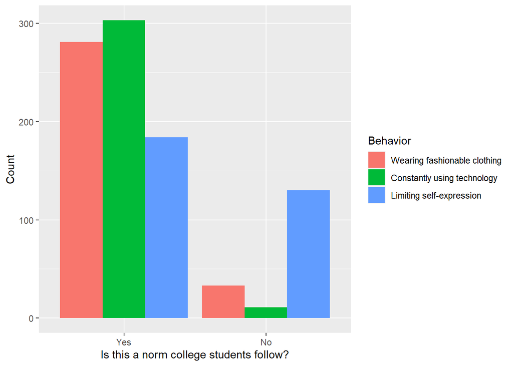

```r
data_clean %>%
  filter(Is_Norm != "NA") %>%
  ggplot(aes(x = Is_Norm, fill = Behavior)) +
  geom_bar(position = "dodge") +
  labs(x = "Is this a norm college students follow?", y = "Count")
```

## Personal values across the three unpopular behaviors

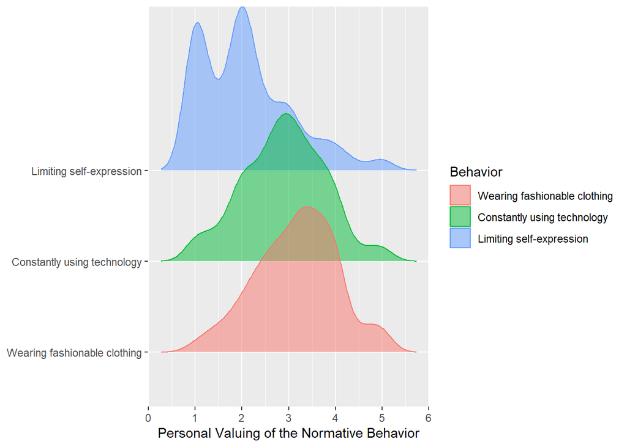

```r
data_clean %>%
  ggplot(aes(x = values_avg, y = Behavior, fill = Behavior, color = Behavior)) +
  geom_density_ridges(alpha = 0.5) +
  labs(x = "Personal Valuing of the Normative Behavior", y = NULL, fill = "Behavior", color = "Behavior")
```

## Perceived descriptive norm across the three unpopular behaviors

- Norm3: I think most other students engage in this behavior.

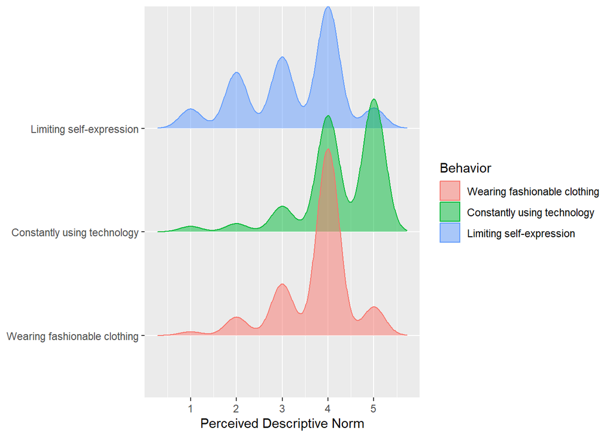

```r
data_clean %>%
  ggplot(aes(x = Norm3, y = Behavior, fill = Behavior, color = Behavior)) +
  geom_density_ridges(alpha = 0.5) +
  labs(x = "Perceived Descriptive Norm", y = NULL, fill = "Behavior", color = "Behavior")
```

## Perceived injunctive norm across the three unpopular behaviors

- Norm4: I think most other students believe college students should engage in this behavior.

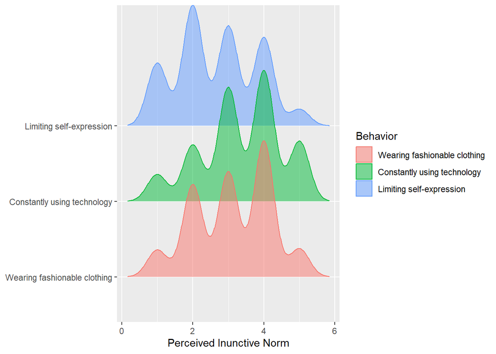

```r
data_clean %>%
  ggplot(aes(x = Norm4, y = Behavior, fill = Behavior, color = Behavior)) +
  geom_density_ridges(alpha = 0.5) +
  labs(x = "Perceived Inunctive Norm", y = NULL, fill = "Behavior", color = "Behavior")
```

# Bivariate Visualizations

## The relationship between personal values and conformity with three unpopular behaviors among college undergraduates

### Scatterplot: Color by group, single graph

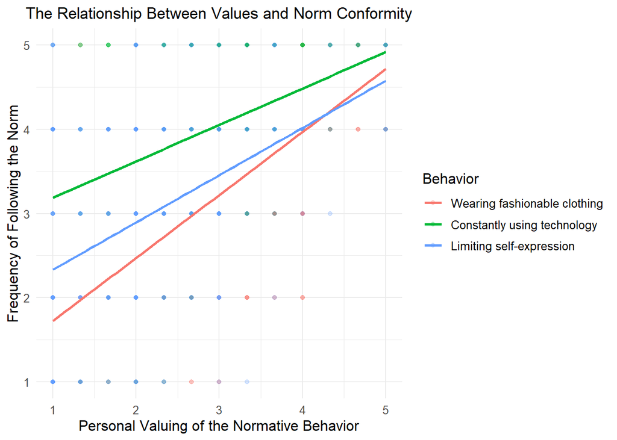

```r
ggplot(data_clean, aes(x = values_avg, y = Conform, color = Behavior)) +
  geom_point(alpha = 0.25) +
  geom_smooth(method = "lm", se = F) +
  labs(title = "The Relationship Between Values and Norm Conformity", x = "Personal Valuing of the Normative Behavior", y = "Frequency of Following the Norm") +
  theme_minimal() +
  theme(text = element_text(size = 12)) +
  theme(plot.title = element_text(size = 13)) +
  theme(plot.title = element_text(hjust = 0.5))
```

### Scatterplot: Add facet wrap by group, separate graphs per group

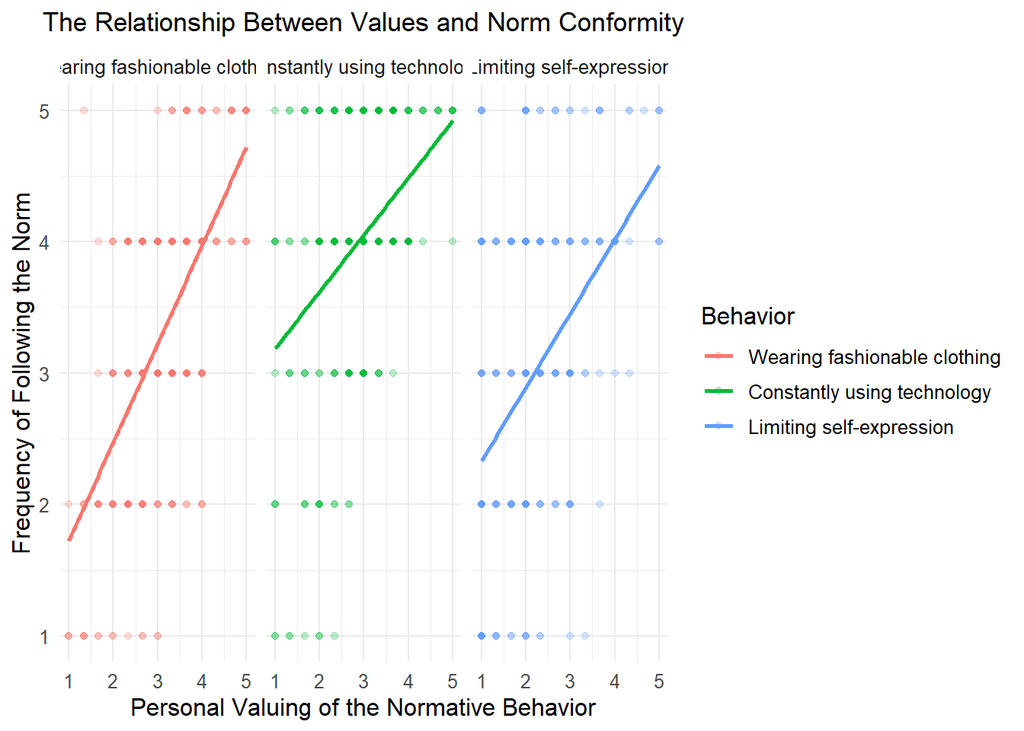

```r
ggplot(data_clean, aes(x = values_avg, y = Conform, color = Behavior)) +
  geom_point(alpha = 0.25) +
  geom_smooth(method = "lm", se = F) +
  facet_wrap(~Behavior) +
  labs(title = "The Relationship Between Values and Norm Conformity", x = "Personal Valuing of the Normative Behavior", y = "Frequency of Following the Norm") +
  theme_minimal() +
  theme(text = element_text(size = 12)) +
  theme(plot.title = element_text(size = 13)) +
  theme(plot.title = element_text(hjust = 0.5))
```

## The relationship between perceived descriptive norm and conformity with three unpopular behaviors among college undergraduates

### Scatterplot: Add facet wrap by group, separate graphs per group

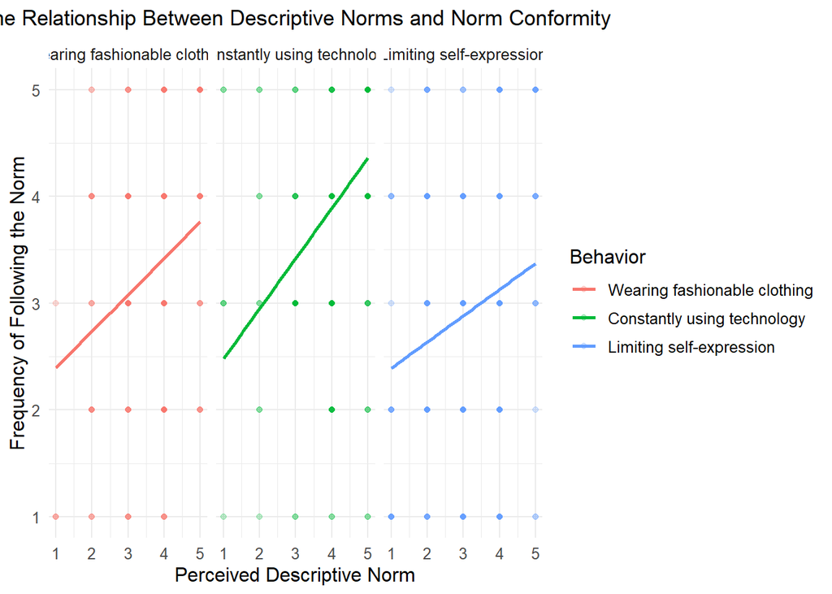

```r
ggplot(data_clean, aes(x = Norm3, y = Conform, color = Behavior)) +
  geom_point(alpha = 0.25) +
  geom_smooth(method = "lm", se = F) +
  facet_wrap(~Behavior) +
  labs(title = "The Relationship Between Descriptive Norms and Norm Conformity", x = "Perceived Descriptive Norm", y = "Frequency of Following the Norm") +
  theme_minimal() +
  theme(text = element_text(size = 12)) +
  theme(plot.title = element_text(size = 13)) +
  theme(plot.title = element_text(hjust = 0.5))
```

## The relationship between perceived injunctive norm and conformity with three unpopular behaviors among college undergraduates

### Scatterplot: Add facet wrap by group, separate graphs per group

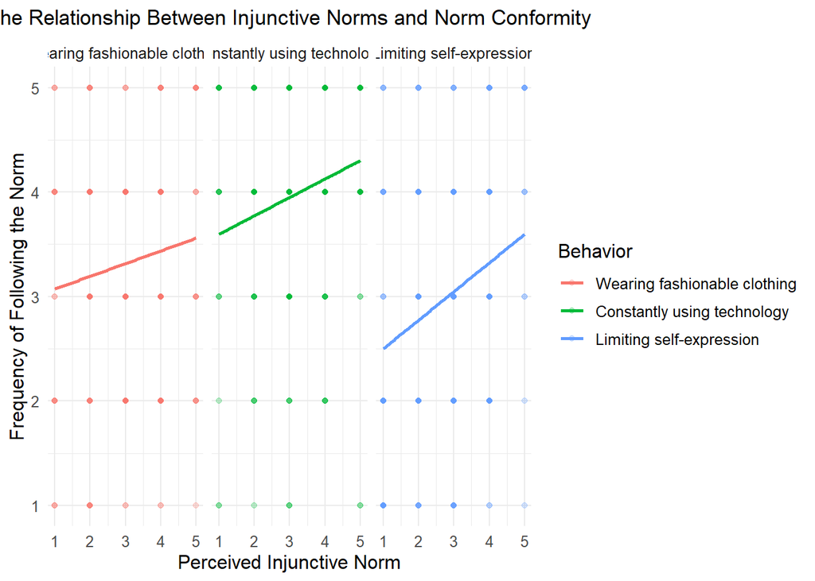

```r
ggplot(data_clean, aes(x = Norm4, y = Conform, color = Behavior)) +
  geom_point(alpha = 0.25) +
  geom_smooth(method = "lm", se = F) +
  facet_wrap(~Behavior) +
  labs(title = "The Relationship Between Injunctive Norms and Norm Conformity", x = "Perceived Injunctive Norm", y = "Frequency of Following the Norm") +
  theme_minimal() +
  theme(text = element_text(size = 12)) +
  theme(plot.title = element_text(size = 13)) +
  theme(plot.title = element_text(hjust = 0.5))
```